# Risk Factor Analysis

## Outcome Variable

**Outcome Variable:** pers_wasted624

## Predictor Variables

**Intervention Variable:** ever_sunderweight06

**Adjustment Set:**

- sex
- arm
- enstunt
- month
- brthmon
- vagbrth
- single
- W_gagebrth
- W_birthwt
- W_birthlen
- W_mage
- W_mhtcm
- W_meducyrs
- W_feducyrs
- W_parity
- delta_month
- delta_brthmon
- delta_vagbrth
- delta_single
- delta_W_gagebrth
- delta_W_birthwt
- delta_W_birthlen
- delta_W_mage
- delta_W_mhtcm
- delta_W_meducyrs
- delta_W_feducyrs
- delta_W_parity

## Stratifying Variables

The analysis was stratified on these variable(s):

- studyid
- country

## Data Summary

| studyid | country | ever_sunderweight06 | pers_wasted624 | n_cell | n |
| --- | --- | --- | --- | --- | --- |
| ki0047075b-MAL-ED | BANGLADESH | 0 | 0 | 211 | 240 |
| ki0047075b-MAL-ED | BANGLADESH | 0 | 1 | 15 | 240 |
| ki0047075b-MAL-ED | BANGLADESH | 1 | 0 | 11 | 240 |
| ki0047075b-MAL-ED | BANGLADESH | 1 | 1 | 3 | 240 |
| ki0047075b-MAL-ED | BRAZIL | 0 | 0 | 205 | 207 |
| ki0047075b-MAL-ED | BRAZIL | 0 | 1 | 2 | 207 |
| ki0047075b-MAL-ED | BRAZIL | 1 | 0 | 0 | 207 |
| ki0047075b-MAL-ED | BRAZIL | 1 | 1 | 0 | 207 |
| ki0047075b-MAL-ED | INDIA | 0 | 0 | 189 | 235 |
| ki0047075b-MAL-ED | INDIA | 0 | 1 | 17 | 235 |
| ki0047075b-MAL-ED | INDIA | 1 | 0 | 18 | 235 |
| ki0047075b-MAL-ED | INDIA | 1 | 1 | 11 | 235 |
| ki0047075b-MAL-ED | NEPAL | 0 | 0 | 223 | 235 |
| ki0047075b-MAL-ED | NEPAL | 0 | 1 | 1 | 235 |
| ki0047075b-MAL-ED | NEPAL | 1 | 0 | 10 | 235 |
| ki0047075b-MAL-ED | NEPAL | 1 | 1 | 1 | 235 |
| ki0047075b-MAL-ED | PERU | 0 | 0 | 260 | 270 |
| ki0047075b-MAL-ED | PERU | 0 | 1 | 2 | 270 |
| ki0047075b-MAL-ED | PERU | 1 | 0 | 8 | 270 |
| ki0047075b-MAL-ED | PERU | 1 | 1 | 0 | 270 |
| ki0047075b-MAL-ED | SOUTH AFRICA | 0 | 0 | 248 | 259 |
| ki0047075b-MAL-ED | SOUTH AFRICA | 0 | 1 | 1 | 259 |
| ki0047075b-MAL-ED | SOUTH AFRICA | 1 | 0 | 9 | 259 |
| ki0047075b-MAL-ED | SOUTH AFRICA | 1 | 1 | 1 | 259 |
| ki0047075b-MAL-ED | TANZANIA, UNITED REPUBLIC OF | 0 | 0 | 237 | 245 |
| ki0047075b-MAL-ED | TANZANIA, UNITED REPUBLIC OF | 0 | 1 | 0 | 245 |
| ki0047075b-MAL-ED | TANZANIA, UNITED REPUBLIC OF | 1 | 0 | 8 | 245 |
| ki0047075b-MAL-ED | TANZANIA, UNITED REPUBLIC OF | 1 | 1 | 0 | 245 |
| ki1000108-CMC-V-BCS-2002 | INDIA | 0 | 0 | 285 | 373 |
| ki1000108-CMC-V-BCS-2002 | INDIA | 0 | 1 | 12 | 373 |

[output cut: 102 more lines]

The following strata were considered:

- studyid: ki0047075b-MAL-ED, country: BANGLADESH
- studyid: ki0047075b-MAL-ED, country: BRAZIL
- studyid: ki0047075b-MAL-ED, country: INDIA
- studyid: ki0047075b-MAL-ED, country: NEPAL
- studyid: ki0047075b-MAL-ED, country: PERU
- studyid: ki0047075b-MAL-ED, country: SOUTH AFRICA
- studyid: ki0047075b-MAL-ED, country: TANZANIA, UNITED REPUBLIC OF
- studyid: ki1000108-CMC-V-BCS-2002, country: INDIA
- studyid: ki1000108-IRC, country: INDIA
- studyid: ki1000109-EE, country: PAKISTAN
- studyid: ki1000109-ResPak, country: PAKISTAN
- studyid: ki1000304b-SAS-CompFeed, country: INDIA
- studyid: ki1000304b-SAS-FoodSuppl, country: INDIA
- studyid: ki1017093-NIH-Birth, country: BANGLADESH
- studyid: ki1017093b-PROVIDE, country: BANGLADESH
- studyid: ki1017093c-NIH-Crypto, country: BANGLADESH
- studyid: ki1066203-TanzaniaChild2, country: TANZANIA, UNITED REPUBLIC OF
- studyid: ki1101329-Keneba, country: GAMBIA
- studyid: ki1112895-Guatemala BSC, country: GUATEMALA
- studyid: ki1113344-GMS-Nepal, country: NEPAL
- studyid: ki1114097-CMIN, country: BANGLADESH
- studyid: ki1114097-CMIN, country: BRAZIL
- studyid: ki1114097-CMIN, country: GUINEA-BISSAU
- studyid: ki1114097-CMIN, country: PERU
- studyid: ki1114097-CONTENT, country: PERU
- studyid: ki1119695-PROBIT, country: BELARUS
- studyid: ki1126311-ZVITAMBO, country: ZIMBABWE
- studyid: ki1135781-COHORTS, country: GUATEMALA
- studyid: ki1135781-COHORTS, country: INDIA
- studyid: ki1135781-COHORTS, country: PHILIPPINES
- studyid: ki1148112-LCNI-5, country: MALAWI
- studyid: kiGH5241-JiVitA-3, country: BANGLADESH
- studyid: kiGH5241-JiVitA-4, country: BANGLADESH

### Dropped Strata

Some strata were dropped due to rare outcomes:

- studyid: ki0047075b-MAL-ED, country: BANGLADESH
- studyid: ki0047075b-MAL-ED, country: BRAZIL
- studyid: ki0047075b-MAL-ED, country: NEPAL
- studyid: ki0047075b-MAL-ED, country: PERU
- studyid: ki0047075b-MAL-ED, country: SOUTH AFRICA
- studyid: ki0047075b-MAL-ED, country: TANZANIA, UNITED REPUBLIC OF
- studyid: ki1112895-Guatemala BSC, country: GUATEMALA
- studyid: ki1114097-CMIN, country: BRAZIL
- studyid: ki1114097-CMIN, country: PERU
- studyid: ki1114097-CONTENT, country: PERU
- studyid: ki1119695-PROBIT, country: BELARUS

## Methods Detail

We’re interested in the causal parameters $E[Y_a]$ for all values of $a \in \mathcal{A}$. These parameters represent the mean outcome if, possibly contrary to fact, we intervened to set all units to have $A=a$. Under the randomization and positivity assumptions, these are identified by the statistical parameters $\psi_a=E_W[E_{Y|A,W}(Y|A=a,W)]$. In addition, we’re interested in the mean of $Y$, $E[Y]$ under no intervention (the observed mean). We will estimate these parameters by using SuperLearner to fit the relevant likelihood factors – $E_{Y|A,W}(Y|A=a,W)$ and $p(A=a|W)$, and then updating our likelihood fit using a joint TMLE.

For unadjusted analyses ($W=\{\}$), initial likelihoods were estimated using Lrnr_glm to estimate the simple $E(Y|A)$ and Lrnr_mean to estimate $p(A)$. For adjusted analyses, a small library containing Lrnr_glmnet, Lrnr_xgboost, and Lrnr_mean was used.

Having estimated these parameters, we will then use the delta method to estimate relative risks and attributable risks relative to a prespecified baseline level of $A$.

# Results Detail

## Results Plots

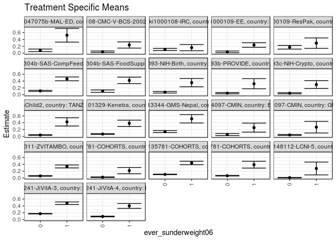

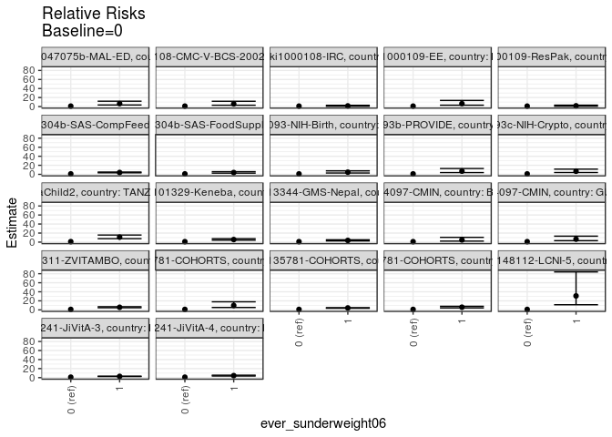

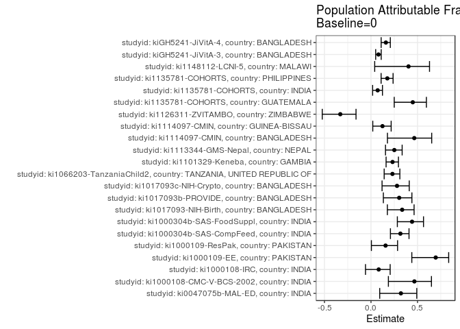

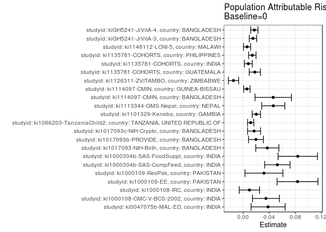

## Results Table

### Parameter: TSM

| studyid | country | intervention_level | baseline_level | estimate | ci_lower | ci_upper |
| --- | --- | --- | --- | --- | --- | --- |
| ki0047075b-MAL-ED | INDIA | 0 | NA | 0.0808377 | 0.0429248 | 0.1187505 |
| ki0047075b-MAL-ED | INDIA | 1 | NA | 0.5231071 | 0.3221540 | 0.7240601 |
| ki1000108-CMC-V-BCS-2002 | INDIA | 0 | NA | 0.0400557 | 0.0175740 | 0.0625374 |
| ki1000108-CMC-V-BCS-2002 | INDIA | 1 | NA | 0.2379940 | 0.1461952 | 0.3297929 |
| ki1000108-IRC | INDIA | 0 | NA | 0.1073487 | 0.0745336 | 0.1401638 |
| ki1000108-IRC | INDIA | 1 | NA | 0.1599437 | 0.0690767 | 0.2508106 |
| ki1000109-EE | PAKISTAN | 0 | NA | 0.0365297 | 0.0116498 | 0.0614095 |
| ki1000109-EE | PAKISTAN | 1 | NA | 0.2371795 | 0.1703427 | 0.3040162 |
| ki1000109-ResPak | PAKISTAN | 0 | NA | 0.1723576 | 0.1179104 | 0.2268048 |
| ki1000109-ResPak | PAKISTAN | 1 | NA | 0.2928599 | 0.1405416 | 0.4451782 |
| ki1000304b-SAS-CompFeed | INDIA | 0 | NA | 0.1137559 | 0.0971181 | 0.1303937 |
| ki1000304b-SAS-CompFeed | INDIA | 1 | NA | 0.4650547 | 0.4095840 | 0.5205254 |
| ki1000304b-SAS-FoodSuppl | INDIA | 0 | NA | 0.1061677 | 0.0706971 | 0.1416383 |
| ki1000304b-SAS-FoodSuppl | INDIA | 1 | NA | 0.4197504 | 0.3242485 | 0.5152523 |
| ki1017093-NIH-Birth | BANGLADESH | 0 | NA | 0.0737657 | 0.0494620 | 0.0980694 |
| ki1017093-NIH-Birth | BANGLADESH | 1 | NA | 0.3535120 | 0.2330390 | 0.4739849 |
| ki1017093b-PROVIDE | BANGLADESH | 0 | NA | 0.0453364 | 0.0282698 | 0.0624029 |
| ki1017093b-PROVIDE | BANGLADESH | 1 | NA | 0.3220981 | 0.1741441 | 0.4700522 |
| ki1017093c-NIH-Crypto | BANGLADESH | 0 | NA | 0.0434163 | 0.0280994 | 0.0587332 |
| ki1017093c-NIH-Crypto | BANGLADESH | 1 | NA | 0.2969742 | 0.1817620 | 0.4121864 |
| ki1066203-TanzaniaChild2 | TANZANIA, UNITED REPUBLIC OF | 0 | NA | 0.0388936 | 0.0303268 | 0.0474604 |
| ki1066203-TanzaniaChild2 | TANZANIA, UNITED REPUBLIC OF | 1 | NA | 0.4239789 | 0.3028870 | 0.5450708 |
| ki1101329-Keneba | GAMBIA | 0 | NA | 0.0673385 | 0.0565069 | 0.0781701 |
| ki1101329-Keneba | GAMBIA | 1 | NA | 0.3811522 | 0.2891655 | 0.4731389 |
| ki1113344-GMS-Nepal | NEPAL | 0 | NA | 0.1384306 | 0.1087800 | 0.1680812 |
| ki1113344-GMS-Nepal | NEPAL | 1 | NA | 0.5142318 | 0.3914774 | 0.6369862 |
| ki1114097-CMIN | BANGLADESH | 0 | NA | 0.0530645 | 0.0220637 | 0.0840654 |
| ki1114097-CMIN | BANGLADESH | 1 | NA | 0.2554947 | 0.1234399 | 0.3875495 |
| ki1114097-CMIN | GUINEA-BISSAU | 0 | NA | 0.0413306 | 0.0289377 | 0.0537236 |
| ki1114097-CMIN | GUINEA-BISSAU | 1 | NA | 0.2692308 | 0.0986511 | 0.4398105 |
| ki1126311-ZVITAMBO | ZIMBABWE | 0 | NA | 0.0592756 | 0.0508277 | 0.0677235 |
| ki1126311-ZVITAMBO | ZIMBABWE | 1 | NA | 0.3377248 | 0.2947811 | 0.3806686 |
| ki1135781-COHORTS | GUATEMALA | 0 | NA | 0.0220812 | 0.0124764 | 0.0316861 |
| ki1135781-COHORTS | GUATEMALA | 1 | NA | 0.2149022 | 0.1238787 | 0.3059258 |
| ki1135781-COHORTS | INDIA | 0 | NA | 0.1037455 | 0.0957427 | 0.1117483 |
| ki1135781-COHORTS | INDIA | 1 | NA | 0.4391432 | 0.3884036 | 0.4898829 |
| ki1135781-COHORTS | PHILIPPINES | 0 | NA | 0.0663330 | 0.0570170 | 0.0756491 |
| ki1135781-COHORTS | PHILIPPINES | 1 | NA | 0.3885962 | 0.2883038 | 0.4888885 |
| ki1148112-LCNI-5 | MALAWI | 0 | NA | 0.0089974 | 0.0023418 | 0.0156531 |
| ki1148112-LCNI-5 | MALAWI | 1 | NA | 0.2777778 | 0.0904991 | 0.4650565 |
| kiGH5241-JiVitA-3 | BANGLADESH | 0 | NA | 0.1727698 | 0.1651710 | 0.1803685 |
| kiGH5241-JiVitA-3 | BANGLADESH | 1 | NA | 0.4798541 | 0.4425811 | 0.5171271 |
| kiGH5241-JiVitA-4 | BANGLADESH | 0 | NA | 0.0901848 | 0.0802699 | 0.1000997 |
| kiGH5241-JiVitA-4 | BANGLADESH | 1 | NA | 0.3995760 | 0.3291025 | 0.4700494 |

### Parameter: E(Y)

| studyid | country | intervention_level | baseline_level | estimate | ci_lower | ci_upper |
| --- | --- | --- | --- | --- | --- | --- |
| ki0047075b-MAL-ED | INDIA | NA | NA | 0.1191489 | 0.0776405 | 0.1606574 |
| ki1000108-CMC-V-BCS-2002 | INDIA | NA | NA | 0.0750670 | 0.0482904 | 0.1018437 |
| ki1000108-IRC | INDIA | NA | NA | 0.1170732 | 0.0859146 | 0.1482317 |
| ki1000109-EE | PAKISTAN | NA | NA | 0.1200000 | 0.0870660 | 0.1529340 |
| ki1000109-ResPak | PAKISTAN | NA | NA | 0.2043478 | 0.1521230 | 0.2565727 |
| ki1000304b-SAS-CompFeed | INDIA | NA | NA | 0.1663067 | 0.1478935 | 0.1847199 |
| ki1000304b-SAS-FoodSuppl | INDIA | NA | NA | 0.1900000 | 0.1515071 | 0.2284929 |
| ki1017093-NIH-Birth | BANGLADESH | NA | NA | 0.1109057 | 0.0844206 | 0.1373909 |
| ki1017093b-PROVIDE | BANGLADESH | NA | NA | 0.0650407 | 0.0455353 | 0.0845460 |
| ki1017093c-NIH-Crypto | BANGLADESH | NA | NA | 0.0602740 | 0.0429977 | 0.0775502 |
| ki1066203-TanzaniaChild2 | TANZANIA, UNITED REPUBLIC OF | NA | NA | 0.0505451 | 0.0409848 | 0.0601054 |
| ki1101329-Keneba | GAMBIA | NA | NA | 0.0876266 | 0.0759950 | 0.0992582 |
| ki1113344-GMS-Nepal | NEPAL | NA | NA | 0.1847458 | 0.1534039 | 0.2160876 |
| ki1114097-CMIN | BANGLADESH | NA | NA | 0.0992063 | 0.0622241 | 0.1361886 |
| ki1114097-CMIN | GUINEA-BISSAU | NA | NA | 0.0471513 | 0.0341242 | 0.0601783 |
| ki1126311-ZVITAMBO | ZIMBABWE | NA | NA | 0.0445669 | 0.0406656 | 0.0484683 |
| ki1135781-COHORTS | GUATEMALA | NA | NA | 0.0400782 | 0.0280529 | 0.0521035 |
| ki1135781-COHORTS | INDIA | NA | NA | 0.1117877 | 0.1043506 | 0.1192249 |
| ki1135781-COHORTS | PHILIPPINES | NA | NA | 0.0804557 | 0.0703953 | 0.0905161 |
| ki1148112-LCNI-5 | MALAWI | NA | NA | 0.0150754 | 0.0066051 | 0.0235457 |
| kiGH5241-JiVitA-3 | BANGLADESH | NA | NA | 0.1879125 | 0.1813641 | 0.1944608 |
| kiGH5241-JiVitA-4 | BANGLADESH | NA | NA | 0.1073532 | 0.0971813 | 0.1175251 |

### Parameter: RR

| studyid | country | intervention_level | baseline_level | estimate | ci_lower | ci_upper |
| --- | --- | --- | --- | --- | --- | --- |
| ki0047075b-MAL-ED | INDIA | 0 | 0 | 1.000000 | 1.0000000 | 1.000000 |
| ki0047075b-MAL-ED | INDIA | 1 | 0 | 6.471080 | 3.5254526 | 11.877873 |
| ki1000108-CMC-V-BCS-2002 | INDIA | 0 | 0 | 1.000000 | 1.0000000 | 1.000000 |
| ki1000108-CMC-V-BCS-2002 | INDIA | 1 | 0 | 5.941583 | 2.9947167 | 11.788231 |
| ki1000108-IRC | INDIA | 0 | 0 | 1.000000 | 1.0000000 | 1.000000 |
| ki1000108-IRC | INDIA | 1 | 0 | 1.489945 | 0.7810581 | 2.842216 |
| ki1000109-EE | PAKISTAN | 0 | 0 | 1.000000 | 1.0000000 | 1.000000 |
| ki1000109-EE | PAKISTAN | 1 | 0 | 6.492788 | 3.1068548 | 13.568803 |
| ki1000109-ResPak | PAKISTAN | 0 | 0 | 1.000000 | 1.0000000 | 1.000000 |
| ki1000109-ResPak | PAKISTAN | 1 | 0 | 1.699141 | 0.9220752 | 3.131068 |
| ki1000304b-SAS-CompFeed | INDIA | 0 | 0 | 1.000000 | 1.0000000 | 1.000000 |
| ki1000304b-SAS-CompFeed | INDIA | 1 | 0 | 4.088182 | 3.3331653 | 5.014222 |
| ki1000304b-SAS-FoodSuppl | INDIA | 0 | 0 | 1.000000 | 1.0000000 | 1.000000 |
| ki1000304b-SAS-FoodSuppl | INDIA | 1 | 0 | 3.953655 | 2.6375671 | 5.926441 |
| ki1017093-NIH-Birth | BANGLADESH | 0 | 0 | 1.000000 | 1.0000000 | 1.000000 |
| ki1017093-NIH-Birth | BANGLADESH | 1 | 0 | 4.792364 | 2.9825674 | 7.700330 |
| ki1017093b-PROVIDE | BANGLADESH | 0 | 0 | 1.000000 | 1.0000000 | 1.000000 |
| ki1017093b-PROVIDE | BANGLADESH | 1 | 0 | 7.104632 | 3.9234011 | 12.865315 |
| ki1017093c-NIH-Crypto | BANGLADESH | 0 | 0 | 1.000000 | 1.0000000 | 1.000000 |
| ki1017093c-NIH-Crypto | BANGLADESH | 1 | 0 | 6.840160 | 4.0503405 | 11.551570 |
| ki1066203-TanzaniaChild2 | TANZANIA, UNITED REPUBLIC OF | 0 | 0 | 1.000000 | 1.0000000 | 1.000000 |
| ki1066203-TanzaniaChild2 | TANZANIA, UNITED REPUBLIC OF | 1 | 0 | 10.900997 | 7.5987242 | 15.638379 |
| ki1101329-Keneba | GAMBIA | 0 | 0 | 1.000000 | 1.0000000 | 1.000000 |
| ki1101329-Keneba | GAMBIA | 1 | 0 | 5.660238 | 4.2354898 | 7.564248 |
| ki1113344-GMS-Nepal | NEPAL | 0 | 0 | 1.000000 | 1.0000000 | 1.000000 |
| ki1113344-GMS-Nepal | NEPAL | 1 | 0 | 3.714726 | 2.6961648 | 5.118080 |
| ki1114097-CMIN | BANGLADESH | 0 | 0 | 1.000000 | 1.0000000 | 1.000000 |
| ki1114097-CMIN | BANGLADESH | 1 | 0 | 4.814793 | 2.2010169 | 10.532510 |
| ki1114097-CMIN | GUINEA-BISSAU | 0 | 0 | 1.000000 | 1.0000000 | 1.000000 |
| ki1114097-CMIN | GUINEA-BISSAU | 1 | 0 | 6.514071 | 3.2317093 | 13.130242 |
| ki1126311-ZVITAMBO | ZIMBABWE | 0 | 0 | 1.000000 | 1.0000000 | 1.000000 |
| ki1126311-ZVITAMBO | ZIMBABWE | 1 | 0 | 5.697535 | 4.7050539 | 6.899368 |
| ki1135781-COHORTS | GUATEMALA | 0 | 0 | 1.000000 | 1.0000000 | 1.000000 |
| ki1135781-COHORTS | GUATEMALA | 1 | 0 | 9.732341 | 5.3087692 | 17.841886 |
| ki1135781-COHORTS | INDIA | 0 | 0 | 1.000000 | 1.0000000 | 1.000000 |
| ki1135781-COHORTS | INDIA | 1 | 0 | 4.232890 | 3.6836846 | 4.863976 |
| ki1135781-COHORTS | PHILIPPINES | 0 | 0 | 1.000000 | 1.0000000 | 1.000000 |
| ki1135781-COHORTS | PHILIPPINES | 1 | 0 | 5.858259 | 4.3667674 | 7.859178 |
| ki1148112-LCNI-5 | MALAWI | 0 | 0 | 1.000000 | 1.0000000 | 1.000000 |
| ki1148112-LCNI-5 | MALAWI | 1 | 0 | 30.873016 | 11.3476420 | 83.994817 |
| kiGH5241-JiVitA-3 | BANGLADESH | 0 | 0 | 1.000000 | 1.0000000 | 1.000000 |
| kiGH5241-JiVitA-3 | BANGLADESH | 1 | 0 | 2.777420 | 2.5361383 | 3.041655 |
| kiGH5241-JiVitA-4 | BANGLADESH | 0 | 0 | 1.000000 | 1.0000000 | 1.000000 |
| kiGH5241-JiVitA-4 | BANGLADESH | 1 | 0 | 4.430636 | 3.5976283 | 5.456520 |

### Parameter: PAR

| studyid | country | intervention_level | baseline_level | estimate | ci_lower | ci_upper |
| --- | --- | --- | --- | --- | --- | --- |
| ki0047075b-MAL-ED | INDIA | 0 | NA | 0.0383113 | 0.0122242 | 0.0643984 |
| ki1000108-CMC-V-BCS-2002 | INDIA | 0 | NA | 0.0350114 | 0.0143774 | 0.0556454 |
| ki1000108-IRC | INDIA | 0 | NA | 0.0097245 | -0.0058915 | 0.0253404 |
| ki1000109-EE | PAKISTAN | 0 | NA | 0.0834703 | 0.0521549 | 0.1147857 |
| ki1000109-ResPak | PAKISTAN | 0 | NA | 0.0319902 | 0.0028694 | 0.0611110 |
| ki1000304b-SAS-CompFeed | INDIA | 0 | NA | 0.0525508 | 0.0330698 | 0.0720318 |
| ki1000304b-SAS-FoodSuppl | INDIA | 0 | NA | 0.0838323 | 0.0536457 | 0.1140190 |
| ki1017093-NIH-Birth | BANGLADESH | 0 | NA | 0.0371401 | 0.0194517 | 0.0548284 |
| ki1017093b-PROVIDE | BANGLADESH | 0 | NA | 0.0197043 | 0.0083427 | 0.0310659 |
| ki1017093c-NIH-Crypto | BANGLADESH | 0 | NA | 0.0168577 | 0.0069263 | 0.0267892 |
| ki1066203-TanzaniaChild2 | TANZANIA, UNITED REPUBLIC OF | 0 | NA | 0.0116515 | 0.0069033 | 0.0163997 |
| ki1101329-Keneba | GAMBIA | 0 | NA | 0.0202881 | 0.0139720 | 0.0266041 |
| ki1113344-GMS-Nepal | NEPAL | 0 | NA | 0.0463151 | 0.0285711 | 0.0640592 |
| ki1114097-CMIN | BANGLADESH | 0 | NA | 0.0461418 | 0.0182310 | 0.0740527 |
| ki1114097-CMIN | GUINEA-BISSAU | 0 | NA | 0.0058206 | 0.0009254 | 0.0107159 |
| ki1126311-ZVITAMBO | ZIMBABWE | 0 | NA | -0.0147087 | -0.0225540 | -0.0068633 |
| ki1135781-COHORTS | GUATEMALA | 0 | NA | 0.0179970 | 0.0093880 | 0.0266059 |
| ki1135781-COHORTS | INDIA | 0 | NA | 0.0080422 | 0.0019913 | 0.0140932 |
| ki1135781-COHORTS | PHILIPPINES | 0 | NA | 0.0141226 | 0.0084908 | 0.0197545 |
| ki1148112-LCNI-5 | MALAWI | 0 | NA | 0.0060779 | 0.0006315 | 0.0115244 |
| kiGH5241-JiVitA-3 | BANGLADESH | 0 | NA | 0.0151427 | 0.0094445 | 0.0208409 |
| kiGH5241-JiVitA-4 | BANGLADESH | 0 | NA | 0.0171684 | 0.0115952 | 0.0227417 |

### Parameter: PAF

| studyid | country | intervention_level | baseline_level | estimate | ci_lower | ci_upper |
| --- | --- | --- | --- | --- | --- | --- |
| ki0047075b-MAL-ED | INDIA | 0 | NA | 0.3215410 | 0.0936579 | 0.4921270 |
| ki1000108-CMC-V-BCS-2002 | INDIA | 0 | NA | 0.4664014 | 0.1870079 | 0.6497783 |
| ki1000108-IRC | INDIA | 0 | NA | 0.0830630 | -0.0590027 | 0.2060706 |
| ki1000109-EE | PAKISTAN | 0 | NA | 0.6955860 | 0.4387525 | 0.8348894 |
| ki1000109-ResPak | PAKISTAN | 0 | NA | 0.1565479 | 0.0041816 | 0.2856012 |
| ki1000304b-SAS-CompFeed | INDIA | 0 | NA | 0.3159874 | 0.2088952 | 0.4085825 |
| ki1000304b-SAS-FoodSuppl | INDIA | 0 | NA | 0.4412227 | 0.2832138 | 0.5644000 |
| ki1017093-NIH-Birth | BANGLADESH | 0 | NA | 0.3348795 | 0.1759998 | 0.4631248 |
| ki1017093b-PROVIDE | BANGLADESH | 0 | NA | 0.3029535 | 0.1329716 | 0.4396103 |
| ki1017093c-NIH-Crypto | BANGLADESH | 0 | NA | 0.2796847 | 0.1188851 | 0.4111391 |
| ki1066203-TanzaniaChild2 | TANZANIA, UNITED REPUBLIC OF | 0 | NA | 0.2305170 | 0.1416902 | 0.3101511 |
| ki1101329-Keneba | GAMBIA | 0 | NA | 0.2315285 | 0.1622886 | 0.2950455 |
| ki1113344-GMS-Nepal | NEPAL | 0 | NA | 0.2506966 | 0.1559278 | 0.3348251 |
| ki1114097-CMIN | BANGLADESH | 0 | NA | 0.4651096 | 0.1767940 | 0.6524469 |
| ki1114097-CMIN | GUINEA-BISSAU | 0 | NA | 0.1234459 | 0.0191191 | 0.2166765 |
| ki1126311-ZVITAMBO | ZIMBABWE | 0 | NA | -0.3300357 | -0.5238031 | -0.1609078 |
| ki1135781-COHORTS | GUATEMALA | 0 | NA | 0.4490459 | 0.2497462 | 0.5954031 |
| ki1135781-COHORTS | INDIA | 0 | NA | 0.0719421 | 0.0175664 | 0.1233082 |
| ki1135781-COHORTS | PHILIPPINES | 0 | NA | 0.1755331 | 0.1086927 | 0.2373609 |
| ki1148112-LCNI-5 | MALAWI | 0 | NA | 0.4031705 | 0.0398585 | 0.6290074 |
| kiGH5241-JiVitA-3 | BANGLADESH | 0 | NA | 0.0805838 | 0.0503099 | 0.1098927 |
| kiGH5241-JiVitA-4 | BANGLADESH | 0 | NA | 0.1599247 | 0.1092392 | 0.2077260 |